# Recording instructions for Margaux Dubuis

G. Moroz

last verssion of this file: [online](https://agricolamz.github.io/2019.06.27_Dubui_recording_instructions/Dubui_recording_instructions.html)

## Packages

First you need to install these packages:

```r
install.packages("readxl")
devtools::install_github("agricolamz/lingfieldwork")
```

## Collecting stimuli

First, you need to decide what do you want to record (selected forms, sentences, whatever) and list all stimuli in the file `stimuli.xlsx` with the following columns `stimuli`, `translation` (it is better not to use complicated symbols like ʰ etc.), and `comments`. Put the file in some folder (`path`), open RStudio, copy and run the following lines:

```r
setwd("...") # sets a path to your file, remmeber about slashes
stimuli <- readxl::read_xlsx("stimuli.xlsx") # read from your file
lingfieldwork::create_presentation(stimuli$stimuli,
                                   stimuli$translation, # optional
                                   output = "html")
```

This code will create a `stimuli_prezi.html` for you. Each slide in the presentation contains a word that you expect and its translation.

## Recording

Record your stimuli. Use two recorders:

1. cheap recorder for everything (it could be even your phone) and small settings (mp3, small bitrate)
2. normal one with a good quality and settings (wav, with sample frequency around 40 kHz)

Do have a notebook and a pencil: you need to record sociolinguistic information about speaker, numbers of recording that you need to through out, correct spelling of some words that this particular speaker pronounce in a strange way.

## Rename your files

As fast as you can, you need to rename your files. You need to create a separate folder for each speaker and put there all recordings from this session. If you have multiple sessions with the same speaker (lets treat one presentation as one session) create a separate folder for each session. Keep recordings from different recorders in a different folder. Make a backup of all created recordings on the hard drive and computer and remove all recordings from recorder.

For renaming files you need to put all files into a folder (there should be no files other then wav). Double check the number of the files should be the same as the number of stimuli. In the prefix argument put all additional information such as date, code of the informant, gender and year of birth etc

```r
setwd("...") # sets a path to the folder with sounds
lingfieldwork::rename_soundfiles(prefix = "...",
                                 stimuli = stimuli$stimuli,
                                 translations = stimuli$translation)
```

By default this function creates a backup of your files. So check whether renaming succeed randomly listening some files. If everything went good delete the backup folder.

## Concatenate all files

The next task that you want to do is to create automatically annotation for each word from multiple files (it is analogue of the “Concatenate recoverably” in Praat):

```r
setwd("...")  # sets a path to the folder with renamed sounds
lingfieldwork::concatenate_soundfiles(filename = "all") # you could rename it with speakere code or something
```

If everything went good now you have a new file and a TextGrid with all your files.

## What is the next?

You can annotate the words:

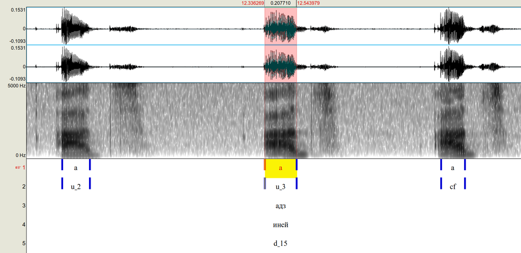

It is better to annotate just borders and automatically fill it with a script (look at my [Praat script](https://github.com/agricolamz/annotate_from_text_file_in_praat), I’ll write a function for `lingfieldwork` that will do the same).

Having this kind of annotation it is possible to use [this Praat script](https://raw.githubusercontent.com/agricolamz/get_pitch_formants_duration/master/get_formants_duration.praat) for extracting pitch (see [some instructions](https://github.com/agricolamz/get_pitch_formants_duration)), duration and formants.